# Monte Carlo Simulation for Option Pricing

Jimmy Kane

## 📘 Abstract

| Model.Assumptions |
| --- |
| 📈 The stock price follows Geometric Brownian Motion (GBM) with constant volatility. \| |
| 💵 The risk-free interest rate remains constant throughout the option’s life. \| |
| 🧾 There are no transaction costs, taxes, or dividend payments. \| |
| 📊 Markets are frictionless, and trading can occur continuously. \| |
| ⏳ The option is European-style and can only be exercised at expiration. \| |
| 🔁 Stock returns are normally distributed and independent over time. \| |
| 🎲 Antithetic variates are used to reduce simulation variance. \| |

## 🔧 Step 1: Define Inputs

We extract user-specified parameters from the YAML header including the stock ticker, strike price, time to maturity, and risk-free rate. We also define the number of simulations and time steps for the Monte Carlo simulation.

```r
stock_ticker <- params$stock_ticker
K <- params$K
T <- params$T
r <- params$r
n_sim <- 10000
n_steps <- 252
```

## 💻 Step 2: Fetch Stock Price and Implied Volatility

```r
data <- tq_get(stock_ticker)
S0 <- last(data$close)

option_chain <- tryCatch(getOptionChain(stock_ticker, NULL), error = function(e) NULL)

if (!is.null(option_chain) && !is.null(option_chain$calls)) {
  call_chain <- option_chain$calls
  atm_call <- call_chain[which.min(abs(call_chain$Strike - S0)), ]
  iv_sigma <- as.numeric(atm_call$ImpliedVolatility)
} else {
  warning("Options data unavailable. Using fallback sigma = 0.2")
  iv_sigma <- 0.2
}



stock_info <- tibble(
  Parameter = c("Stock Ticker", "Initial Price", "Strike Price", "Implied Volatility", "Time to Maturity", "Risk-Free Rate"),
  Value = c(stock_ticker, round(S0, 2), K, round(iv_sigma, 4), T, r)
)

kable(stock_info, caption = "Simulation Parameters with Implied Volatility") %>%
  kable_styling(bootstrap_options = c("striped", "hover"))
```

Simulation Parameters with Implied Volatility

| Parameter | Value |
| --- | --- |
| Stock Ticker | AAPL |
| Initial Price | 198.53 |
| Strike Price | 105 |
| Implied Volatility | 0.2 |
| Time to Maturity | 1 |
| Risk-Free Rate | 0.05 |

## 📈 Step 3: Simulate GBM Paths (with Variance Reduction)

We simulate stock price paths using Geometric Brownian Motion. Antithetic variates are included for variance reduction, producing two mirrored sets of paths to improve simulation efficiency.

```r
set.seed(123)
simulate_paths <- function(S0, sigma, T, r, n_sim, n_steps) {
  dt <- T / n_steps
  Z <- matrix(rnorm(n_sim * n_steps), nrow = n_sim)
  Z_anti <- -Z

  simulate <- function(Z_mat) {
    S <- matrix(0, n_sim, n_steps + 1)
    S[, 1] <- S0
    for (t in 1:n_steps) {
      S[, t + 1] <- S[, t] * exp((r - 0.5 * sigma^2) * dt + sigma * sqrt(dt) * Z_mat[, t])
    }
    return(S)
  }

  list(norm = simulate(Z), anti = simulate(Z_anti))
}

paths <- simulate_paths(S0, iv_sigma, T, r, n_sim, n_steps)
```

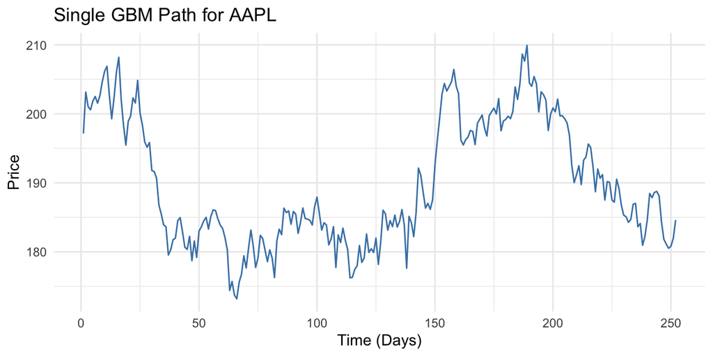

```r
preview_df <- data.frame(Time = 1:n_steps, Price = paths$norm[1, 2:(n_steps+1)])
ggplot(preview_df, aes(x = Time, y = Price)) +
  geom_line(color = "steelblue") +
  labs(title = paste("Single GBM Path for", stock_ticker), x = "Time (Days)", y = "Price") +
  theme_minimal()
```

## 🖼️ Step 4: Visualize 10 Sample Paths

We show 10 randomly simulated stock price paths to illustrate the variability and possible trajectories under GBM.

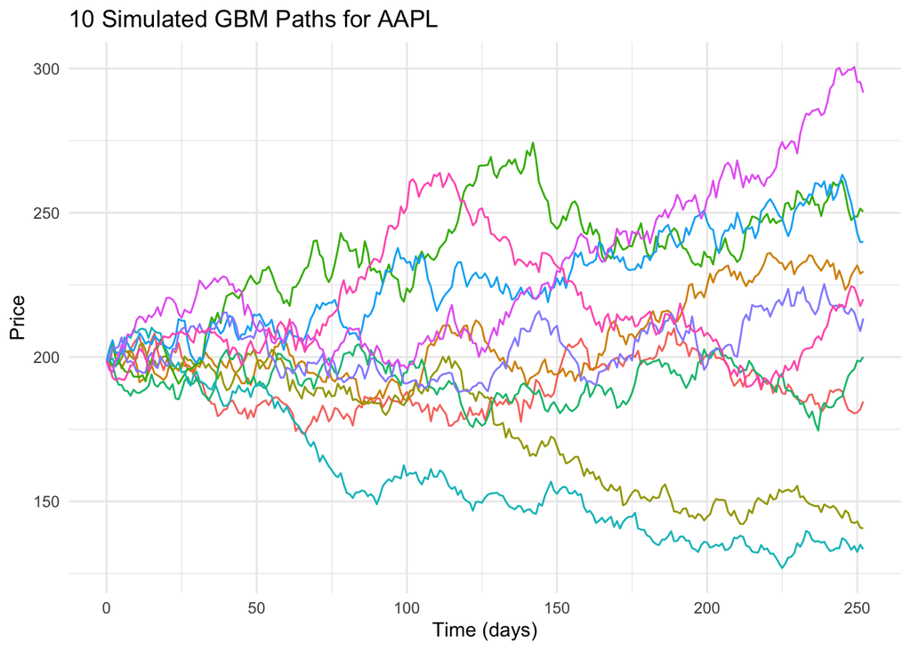

```r
sample_df <- as.data.frame(t(paths$norm[1:10, ]))
sample_df$Time <- 0:n_steps
long_df <- pivot_longer(sample_df, cols = -Time, names_to = "Path", values_to = "Price")

ggplot(long_df, aes(x = Time, y = Price, color = Path)) +
  geom_line() +
  theme_minimal() +
  labs(title = paste("10 Simulated GBM Paths for", stock_ticker), x = "Time (days)", y = "Price") +
  theme(legend.position = "none")
```

## 💵 Step 5: Calculate Option Payoffs

We compute the payoffs for both call and put options using the terminal values of the simulated paths. We also apply discounting and compute confidence intervals.

```r
S_T <- paths$norm[, n_steps + 1]
S_T_anti <- paths$anti[, n_steps + 1]

call_payoff <- 0.5 * (pmax(S_T - K, 0) + pmax(S_T_anti - K, 0))
put_payoff  <- 0.5 * (pmax(K - S_T, 0) + pmax(K - S_T_anti, 0))

call_price <- exp(-r * T) * mean(call_payoff)
put_price  <- exp(-r * T) * mean(put_payoff)

call_se <- sd(call_payoff) / sqrt(n_sim)
put_se <- sd(put_payoff) / sqrt(n_sim)
call_CI <- call_price + c(-1.96, 1.96) * call_se
put_CI <- put_price + c(-1.96, 1.96) * put_se
```

## 📉 Step 6: Histogram of Final Prices

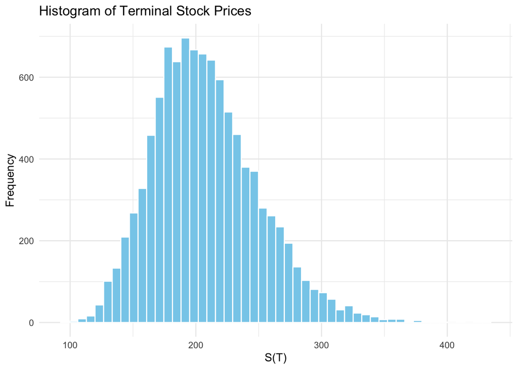

```r
ggplot(data.frame(ST = S_T), aes(x = ST)) +
  geom_histogram(bins = 50, fill = "skyblue", color = "white") +
  labs(title = "Histogram of Terminal Stock Prices", x = "S(T)", y = "Frequency") +
  theme_minimal()
```

The histogram above shows the distribution of stock prices at maturity S(T) based on the simulated paths. It demonstrates the positively skewed nature of the lognormal distribution assumed by Geometric Brownian Motion (GBM). Most of the final prices cluster around the mean, but the long right tail reflects the possibility of large gains—capturing the randomness and asymmetric nature of stock price behavior.

## 📐 Step 7: Compare with Black-Scholes Formula

We compute the Black-Scholes analytical price for the call and put options as a benchmark.

```r
bs_call <- function(S, K, T, r, sigma) {
  d1 <- (log(S/K) + (r + 0.5 * sigma^2)*T) / (sigma * sqrt(T))
  d2 <- d1 - sigma * sqrt(T)
  S * pnorm(d1) - K * exp(-r * T) * pnorm(d2)
}

bs_put <- function(S, K, T, r, sigma) {
  d1 <- (log(S/K) + (r + 0.5 * sigma^2)*T) / (sigma * sqrt(T))
  d2 <- d1 - sigma * sqrt(T)
  K * exp(-r * T) * pnorm(-d2) - S * pnorm(-d1)
}

bs_call_price <- bs_call(S0, K, T, r, iv_sigma)
bs_put_price <- bs_put(S0, K, T, r, iv_sigma)
```

## 🧠 Step 8: Estimate Greeks (Delta, Vega, Theta, Gamma, Rho)

```r
eps <- 0.01

Delta <- (bs_call(S0 + eps, K, T, r, iv_sigma) - bs_call(S0 - eps, K, T, r, iv_sigma)) / (2 * eps)
Vega  <- (bs_call(S0, K, T, r, iv_sigma + eps) - bs_call(S0, K, T, r, iv_sigma - eps)) / (2 * eps)
Theta <- (bs_call(S0, K, T - eps, r, iv_sigma) - bs_call(S0, K, T + eps, r, iv_sigma)) / (2 * eps)
Gamma <- (bs_call(S0 + eps, K, T, r, iv_sigma) - 2 * bs_call(S0, K, T, r, iv_sigma) + bs_call(S0 - eps, K, T, r, iv_sigma)) / (eps^2)
Rho   <- (bs_call(S0, K, T, r + eps, iv_sigma) - bs_call(S0, K, T, r - eps, iv_sigma)) / (2 * eps)
```

## 📊 Step 9: Heatmap of Simulated Call Prices

We simulate option prices across a grid of S0 and volatility values to understand how the call price reacts to changes in input assumptions.

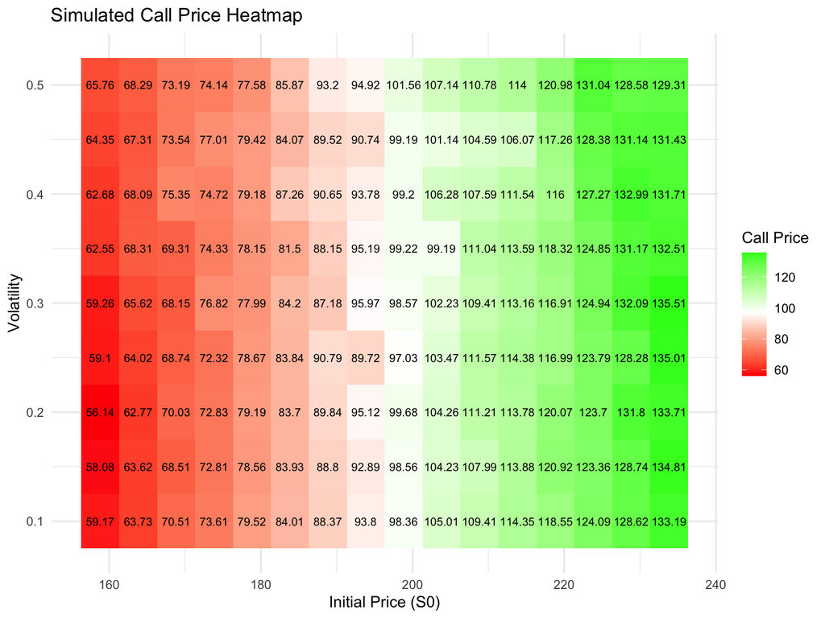

```r
S0_vals <- seq(S0 * 0.8, S0 * 1.2, by = 5)
sigma_vals <- seq(0.1, 0.5, by = 0.05)
grid <- expand.grid(S0 = S0_vals, sigma = sigma_vals)
grid$price <- mapply(function(S0_i, sigma_i) {
  ST <- S0_i * exp((r - 0.5 * sigma_i^2) * T + sigma_i * sqrt(T) * rnorm(1000))
  exp(-r * T) * mean(pmax(ST - K, 0))
}, grid$S0, grid$sigma)
grid$label <- round(grid$price, 2)

ggplot(grid, aes(x = S0, y = sigma, fill = price)) +
  geom_tile() +
  geom_text(aes(label = label), size = 2.8) +
  scale_fill_gradient2(low = "red", high = "green", midpoint = median(grid$price), name = "Call Price") +
  labs(title = "Simulated Call Price Heatmap", x = "Initial Price (S0)", y = "Volatility") +
  theme_minimal()
```

## 📋 Step 10: Results Summary

We summarize all model outputs including Monte Carlo and BSM prices, confidence intervals, and Greeks. The table below compares Monte Carlo and Black-Scholes prices, and lists the Greeks (Delta, Vega, Theta, Gamma, Rho) for the call option. These values help understand how sensitive the option’s price is to changes in various input parameters.

```r
summary_tbl <- tibble(
  Metric = c("Monte Carlo Call Price", "95% CI (Call)", "BSM Call Price",
             "Monte Carlo Put Price", "95% CI (Put)", "BSM Put Price",
             "Delta", "Vega", "Theta", "Gamma", "Rho"),
  Value = c(
    round(call_price, 4),
    paste0("[", round(call_CI[1], 4), ", ", round(call_CI[2], 4), "]"),
    round(bs_call_price, 4),
    round(put_price, 4),
    paste0("[", round(put_CI[1], 4), ", ", round(put_CI[2], 4), "]"),
    round(bs_put_price, 4),
    round(Delta, 4), round(Vega, 4), round(Theta, 4), round(Gamma, 4), round(Rho, 4)
  )
)
kable(summary_tbl, caption = paste("Option Pricing Summary for", stock_ticker)) %>%
  kable_styling(bootstrap_options = c("striped", "hover"), full_width = FALSE)
```

Option Pricing Summary for AAPL

| Metric | Value |
| --- | --- |
| Monte Carlo Call Price | 98.6313 |
| 95% CI (Call) | [98.5161, 98.7465] |
| BSM Call Price | 98.653 |
| Monte Carlo Put Price | 0.0023 |
| 95% CI (Put) | [4e-04, 0.0041] |
| BSM Put Price | 0.0021 |
| Delta | 0.9998 |
| Vega | 0.1598 |
| Theta | -5.0072 |
| Gamma | 0 |
| Rho | 99.8379 |

## 🔮 Future Work

- Add American options (binomial or finite difference methods)
- Create a Shiny dashboard for user interaction
- Support exotic options like barriers or Asians
- Export results to downloadable `.csv` or `.png`

## 🧾 Glossary

- **GBM** – Geometric Brownian Motion, a model for stock prices.
- **Delta** – Sensitivity of option price to the stock price.
- **Vega** – Sensitivity to volatility.
- **Theta** – Sensitivity to time decay.
- **Gamma** – Sensitivity of Delta to price changes.
- **Rho** – Sensitivity to interest rates.
- **Risk-neutral measure** – Assumes expected return is the risk-free rate.
- **Antithetic variates** – A variance reduction technique in simulation.